# Ordinal Regression Models

brms workshop >> 2020-10-22

## Methods for analysis

- Metric models
  - Models that assume outcomes have a continuous distribution, e.g. *t*-test
  - Overestimate information in data; common & “simple”
- [Nonparametric statistics](https://lindeloev.github.io/tests-as-linear/)
  - e.g. analyses of signed ranks (R: `?wilcox.test`, etc.)
  - Underestimate information in data; don’t scale well
- Ordinal models
  - A zoo of models that treat outcomes appropriately as ordered categories
  - Let’s learn more!

## “Analyzing ordinal data with metric models: What could possibly go wrong?”

- [Liddell and Kruschke](https://doi.org/10.1016/j.jesp.2018.08.009) surveyed 68 Psychology articles that analysed ordinal data, and found that *every* article used metric models (2018)
- Metric models on ordinal data can lead to false alarms, failures to detect true effects, distorted effect size estimates, and *inversions* of effects
- Three main shortcomings of metric models:
  - Response categories may not be (e.g. psychologically) equidistant
  - Responses can be non-normally distributed
  - Can treat differences in variances of underlying variable inappropriately
- I don’t mean to be an alarmist, or ignore practical considerations. We don’t know the empirical rate of differences. But…

## “Analyzing ordinal data with metric models: What could possibly go wrong?”

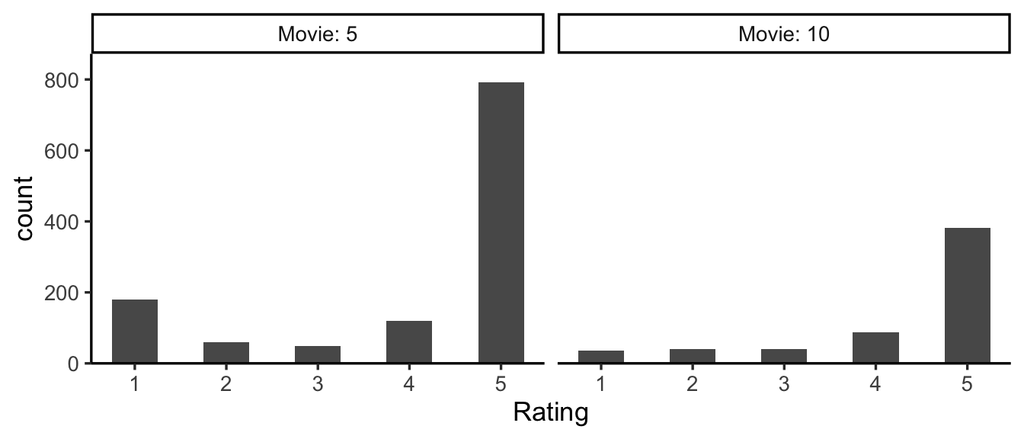

- **Welch’s *t*-test**: Movie 10’s mean rating was significantly greater (Standardized difference = 0.14 [0.23, 0.04])
- **Cumulative probit model**: Movie 10’s mean rating was significantly smaller (Difference = -0.2 [-0.31, -0.09])
- I cherry-picked this example *but it exists*

## Ordinal models

## Ordinal models

- There are many different ordinal models
- We focus on the **cumulative model** (**CM**)
  - Generally the most useful / widely applicable model
- IRT? SDT?
- We introduce CM in the context of a [study](https://www.pnas.org/cgi/doi/10.1073/pnas.1918477117) conducted by (Forstmann et al. 2020)

## Cumulative model

- 1,225 festivalgoes were asked about their mood and substance use, among other things
- The mood rating item, \(Y\), had \(K + 1 = 6\) categories \(1, 2, ..., 6\)

```
#> # A tibble: 6 x 6
#>    Mood    TE Gender   Age Survey H24
#>   <dbl> <dbl> <fct>  <dbl> <fct>  <fct>
#> 1     5     3 1         30 Event3 0
#> 2     5     2 2         50 Event5 0
#> 3     6     7 1         32 Event4 0
#> 4     6     7 2         33 Event2 0
#> 5     5     1 1         22 Event3 0
#> 6     5     7 2         22 Event4 0
```

## Cumulative model

- CM assumes that the observed categorical variable \(Y\) is based on the categorization of an unobserved (“latent”) variable \(\tilde{Y}\) with \(K\) thresholds \(\tau = (\tau_1, \dots, \tau_k)\).
- In this example, \(\tilde{Y}\) has a natural interpretation as current mood
- We assume that \(\tilde{Y}\) has a normal distribution, but other choices are possible, such as logistic (common; default)
- Describe the ordered distribution of responses using thresholds
  - \(Y = k \Leftrightarrow \tau_{k-1} < \tilde{Y} \leq \tau_k\)
- These thresholds give the probability of each response category
  - \(Pr(Y = k) = \Phi(\tau_k) - \Phi(\tau_{k-1})\)
- \(\tilde{Y}\) is amenable to regression (without intercept)
  - \(\tilde{Y} \sim N(\eta, \sigma = 1); \ \eta = b_1x_1 +...\)
  - \(Pr(Y = k \vert \eta) = \Phi(\tau_k - \eta) - \Phi(\tau_{k-1} - \eta)\)

## Cumulative model

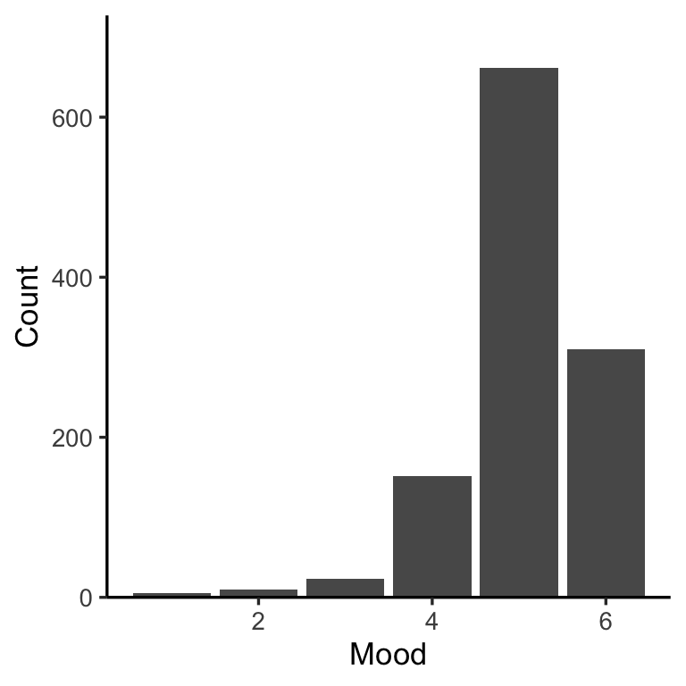

## Cumulative model

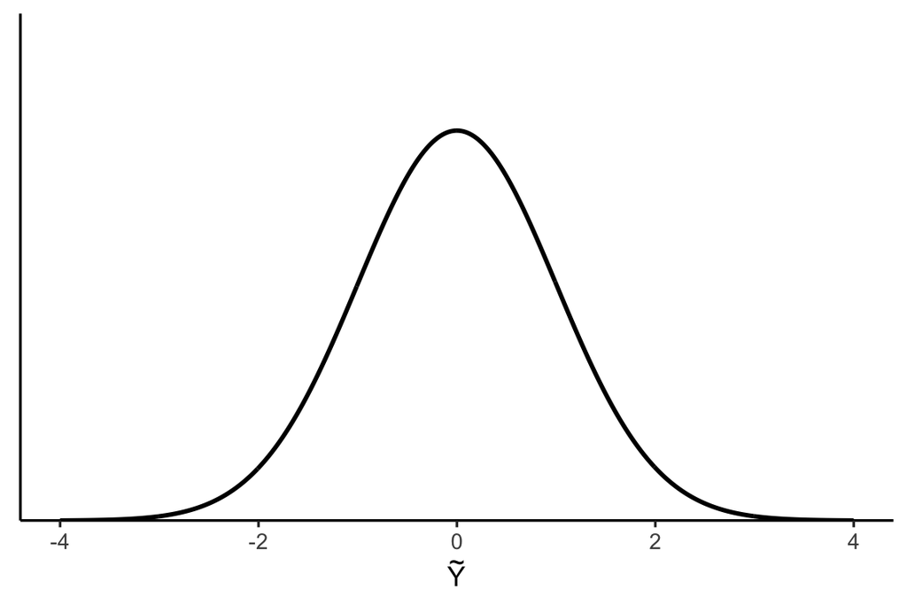

## Cumulative model

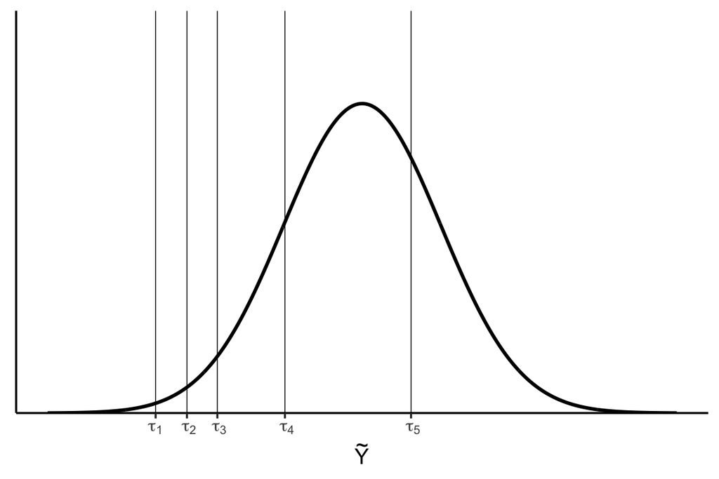

## Cumulative model

```r
tab <- count(dat, Mood) %>%
  mutate(
    p = n / sum(n),
    cp = cumsum(p),
    z = qnorm(cp)
    )
```

```
#> # A tibble: 6 x 5
#>    Mood     n       p      cp       z
#>   <dbl> <int>   <dbl>   <dbl>   <dbl>
#> 1     1     5 0.00431 0.00431  -2.63
#> 2     2    10 0.00862 0.0129   -2.23
#> 3     3    23 0.0198  0.0328   -1.84
#> 4     4   151 0.130   0.163    -0.982
#> 5     5   661 0.570   0.733     0.621
#> 6     6   310 0.267   1       Inf
```

## Cumulative model

```r
tab <- count(dat, Mood) %>%
  mutate(
    p = n / sum(n),
    cp = cumsum(p),
    z = qnorm(cp)
    )
```

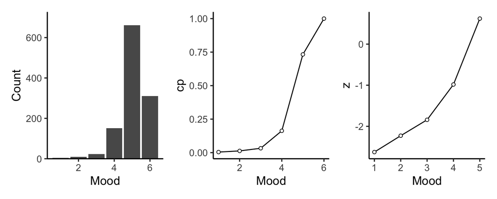

## Cumulative model

### Ok, but how do I do that in practice?

```r
library(brms)  # Bayesian, slower, more flexible
library(ordinal)  # Frequentist, fast, less flexible
```

- So far we have described a weird link function + intercepts
- Write your regressions in R (brms) modelling syntax
- Effects on \(\tilde{Y}\) are directly interpretable

## My first cumulative model

```r
fit1 <- brm(
  Mood ~ H24,
  family = cumulative("probit"),
  data = dat,
  file = here("models/ordinal-1")
)
```

- `family = cumulative()`: CM
- `"probit"`: \(\tilde{Y} \sim {N}(\eta, \sigma = 1)\)
- `Mood ~ H24`: \(\eta = b_1\text{H24}\)
- \(b_1\) is the degree to which mood is greater in people who used hallucinogens in the past 24 hours, compared to people who didn’t use
- Scale of the latent variable (standard deviations)

## Cumulative model

```r
summary(fit1)
```

```
#>  Family: cumulative
#>   Links: mu = probit; disc = identity
#> Formula: Mood ~ H24
#>    Data: dat (Number of observations: 1160)
#> Samples: 4 chains, each with iter = 2000; warmup = 1000; thin = 1;
#>          total post-warmup samples = 4000
#>
#> Population-Level Effects:
#>              Estimate Est.Error l-95% CI u-95% CI Rhat Bulk_ESS Tail_ESS
#> Intercept[1]    -2.63      0.15    -2.95    -2.36 1.00     2260     2188
#> Intercept[2]    -2.20      0.10    -2.40    -2.01 1.00     3723     2673
#> Intercept[3]    -1.80      0.07    -1.94    -1.65 1.00     4210     2968
#> Intercept[4]    -0.93      0.05    -1.02    -0.84 1.00     4155     3639
#> Intercept[5]     0.69      0.04     0.61     0.77 1.00     4199     2974
#> H241             0.39      0.09     0.20     0.57 1.00     4282     2893
#>
#> Family Specific Parameters:
#>      Estimate Est.Error l-95% CI u-95% CI Rhat Bulk_ESS Tail_ESS
#> disc     1.00      0.00     1.00     1.00 1.00     4000     4000
#>
#> Samples were drawn using sampling(NUTS). For each parameter, Bulk_ESS
#> and Tail_ESS are effective sample size measures, and Rhat is the potential
#> scale reduction factor on split chains (at convergence, Rhat = 1).
```

## Cumulative model

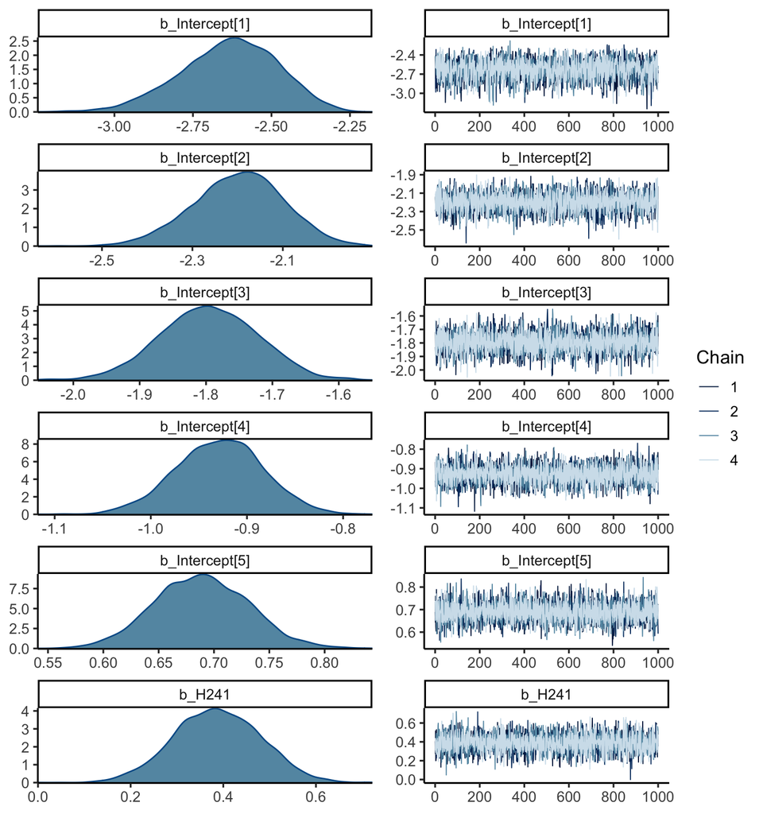

## Cumulative model

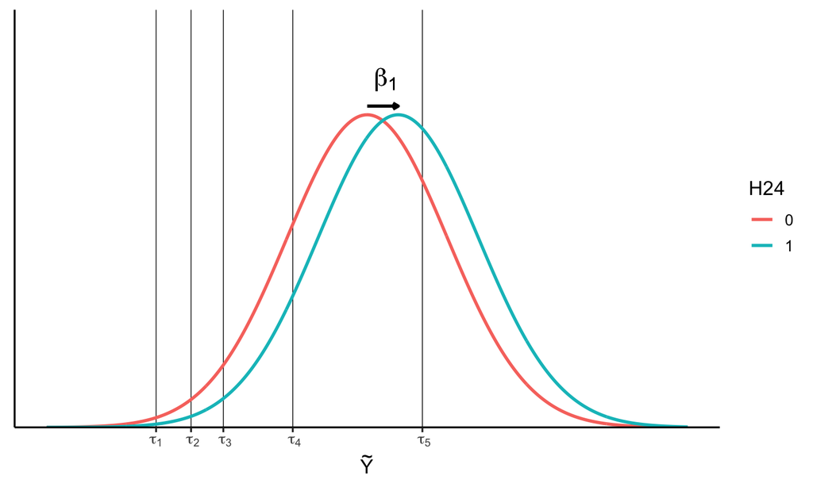

## Cumulative model

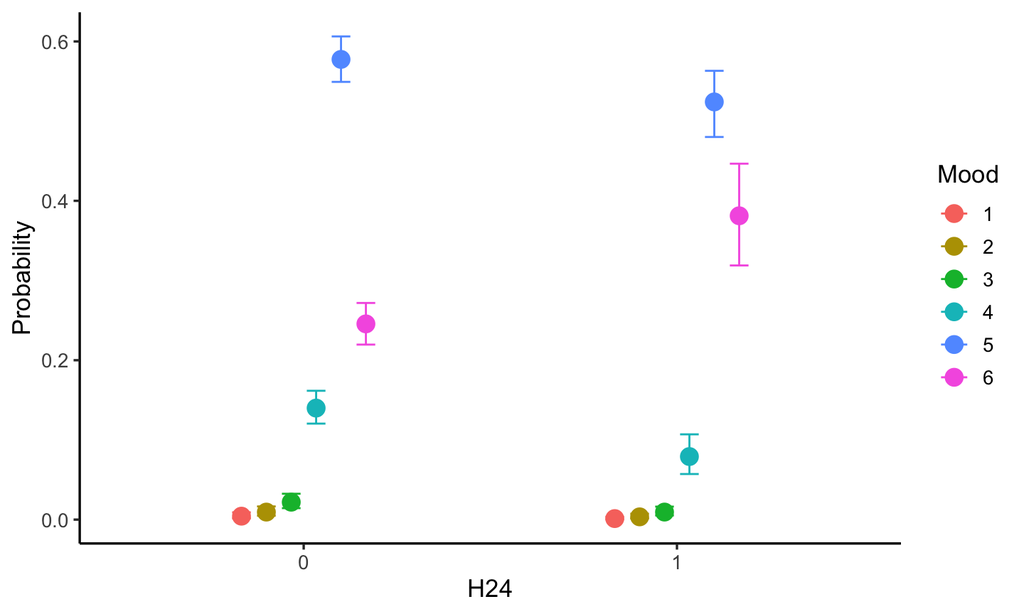

```r
conditional_effects(fit1, categorical = TRUE)
```

## Cumulative model

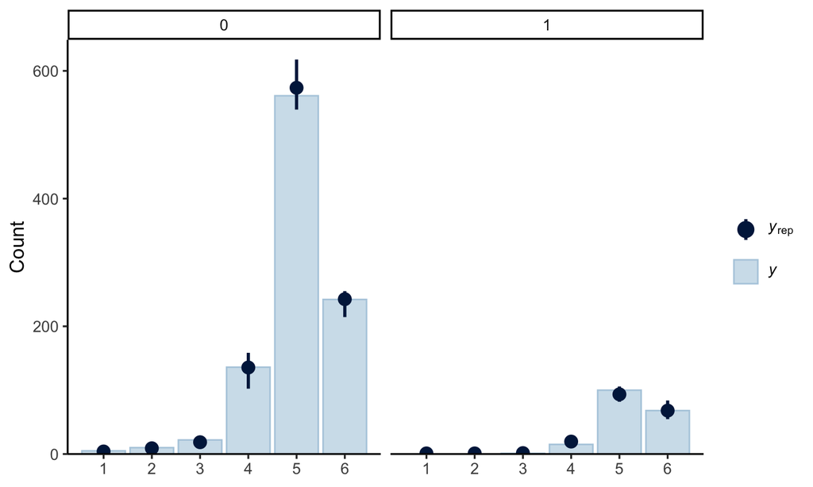

```r
pp_check(fit1, "bars_grouped", group = "H24")
```

## Cumulative model

- It is considered SOP to not assume equal variances when we do e.g. t tests
- Metric models can deal terribly with different variances in \(\tilde{Y}\)
- Cannot simultaneously estimate thresholds and sigma, which is fixed to 1 for baseline group
- However, we can predict the variance (without intercept)
- \(Pr(Y = k \vert \eta, disc) = \Phi(disc \times (\tau_{k+1} - \eta)) - \Phi(disc \times (\tau_{k} - \eta))\)
- `disc`?
  - IRT: Discrimination parameter (slope of response function)
  - Predicted on the log scale \(disc = exp(\eta_{disc})\)
  - \(\sigma\) = \(1/disc\)
- \(\tilde{Y} \sim N(\eta, 1/exp(\eta_{disc})); \ \eta = b_1x_1 +...; \eta_{disc} = g_1x_2 + ...\)

## Cumulative model

```r
fit2 <- brm(
  bf(Mood ~ H24) +
    lf(disc ~ 0 + H24, cmc = FALSE),
  family = cumulative("probit"),
  data = dat,
  file = here("models/ordinal-2")
)
```

## Cumulative model

```
#>  Family: cumulative
#>   Links: mu = probit; disc = log
#> Formula: Mood ~ H24
#>          disc ~ 0 + H24
#>    Data: dat (Number of observations: 1160)
#> Samples: 4 chains, each with iter = 2000; warmup = 1000; thin = 1;
#>          total post-warmup samples = 4000
#>
#> Population-Level Effects:
#>              Estimate Est.Error l-95% CI u-95% CI Rhat Bulk_ESS Tail_ESS
#> Intercept[1]    -2.62      0.16    -2.97    -2.33 1.00     2896     2496
#> Intercept[2]    -2.19      0.10    -2.39    -1.99 1.00     4299     2861
#> Intercept[3]    -1.78      0.07    -1.93    -1.64 1.00     4475     2932
#> Intercept[4]    -0.92      0.05    -1.01    -0.83 1.00     4044     3285
#> Intercept[5]     0.68      0.04     0.60     0.77 1.00     3046     2812
#> H241             0.37      0.09     0.19     0.56 1.00     3973     2541
#> disc_H241        0.08      0.08    -0.09     0.23 1.00     3205     3076
#>
#> Samples were drawn using sampling(NUTS). For each parameter, Bulk_ESS
#> and Tail_ESS are effective sample size measures, and Rhat is the potential
#> scale reduction factor on split chains (at convergence, Rhat = 1).
```

## Cumulative model

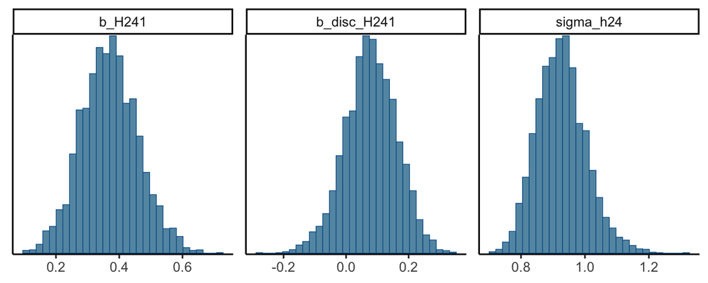

```r
posterior_samples(fit2, pars = "H24") %>%
  mutate(sigma_h24 = 1 / exp(b_disc_H241)) %>%
  mcmc_hist()
```

## Cumulative model

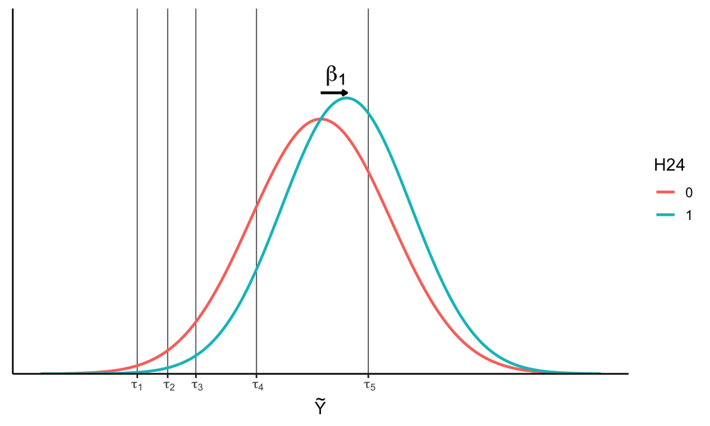

## More ordinal models

## Category specific effects

- Cannot use CM
- Adjacent category model: predict decisions between categories

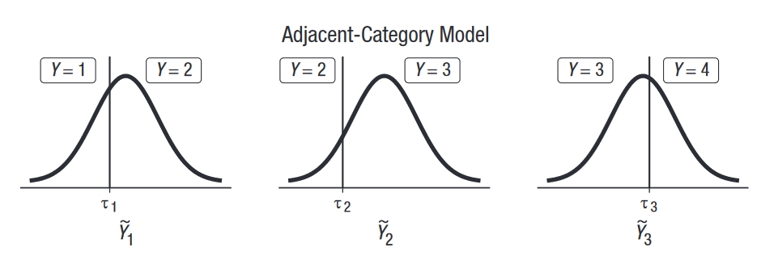

- One problem, however…

```r
table(dat$H24, dat$Mood)
```

```
#>
#>       1   2   3   4   5   6
#>   0   5  10  22 136 561 242
#>   1   0   0   1  15 100  68
```

## Category specific effects

- There are two cells with no observations
- Those category-specific effects won’t be identified
- If only there was a way to inject information to the model…
- Bayes to the rescue!

```r
weakly_informative_prior <- prior(normal(0, 1.5), class = "b")
fit3 <- brm(
  bf(Mood ~ cs(H24)),
  family = acat("probit"),
  prior = weakly_informative_prior,
  data = dat,
  control = list(adapt_delta = .95),
  file = here("models/ordinal-3")
)
```

## Category specific effects

```r
summary(fit3)
```

```
#>  Family: acat
#>   Links: mu = probit; disc = identity
#> Formula: Mood ~ cs(H24)
#>    Data: dat (Number of observations: 1160)
#> Samples: 4 chains, each with iter = 2000; warmup = 1000; thin = 1;
#>          total post-warmup samples = 4000
#>
#> Population-Level Effects:
#>              Estimate Est.Error l-95% CI u-95% CI Rhat Bulk_ESS Tail_ESS
#> Intercept[1]    -0.44      0.32    -1.07     0.19 1.00     4155     3196
#> Intercept[2]    -0.51      0.23    -0.97    -0.08 1.00     3748     2832
#> Intercept[3]    -1.09      0.13    -1.33    -0.84 1.00     3555     2669
#> Intercept[4]    -0.86      0.05    -0.97    -0.76 1.00     3791     3331
#> Intercept[5]     0.52      0.05     0.43     0.61 1.00     4165     2713
#> H241[1]          0.40      1.31    -2.00     3.13 1.00     4561     2766
#> H241[2]          1.02      1.13    -0.98     3.27 1.00     3942     2846
#> H241[3]          0.62      0.51    -0.31     1.70 1.00     4129     2952
#> H241[4]          0.27      0.16    -0.02     0.60 1.00     3933     2751
#> H241[5]          0.28      0.11     0.06     0.49 1.00     4482     3081
#>
#> Family Specific Parameters:
#>      Estimate Est.Error l-95% CI u-95% CI Rhat Bulk_ESS Tail_ESS
#> disc     1.00      0.00     1.00     1.00 1.00     4000     4000
#>
#> Samples were drawn using sampling(NUTS). For each parameter, Bulk_ESS
#> and Tail_ESS are effective sample size measures, and Rhat is the potential
#> scale reduction factor on split chains (at convergence, Rhat = 1).
```

## Category specific effects

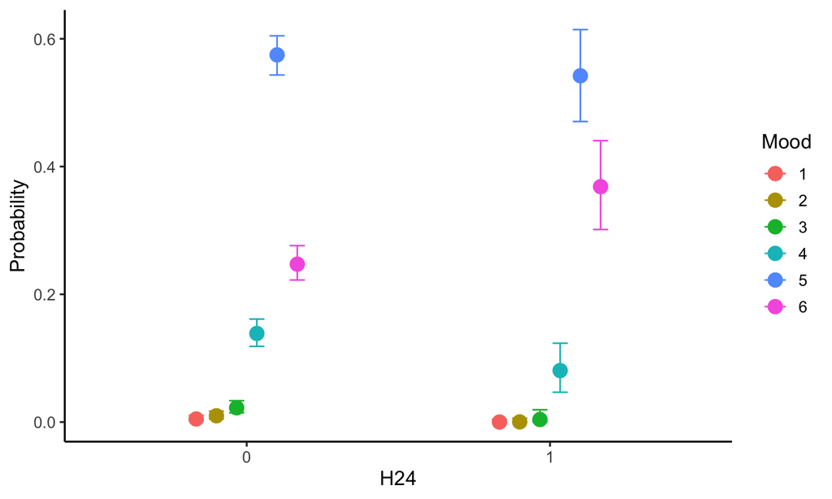

```r
conditional_effects(fit3, categorical = TRUE)
```

## Category specific effects

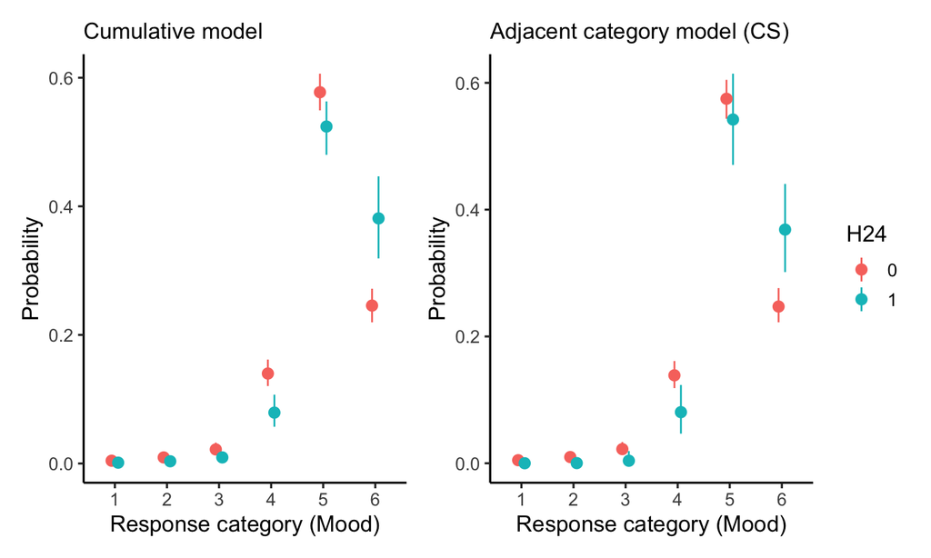

## Model comparison

```r
fit4 <- brm(
  bf(Mood ~ H24),
  family = acat("probit"),
  prior = weakly_informative_prior,
  data = dat,
  file = here("models/ordinal-4")
)
```

## Model comparison

```r
loo(fit1, fit2, fit3, fit4)
```

```
#> Output of model 'fit1':
#>
#> Computed from 4000 by 1160 log-likelihood matrix
#>
#>          Estimate   SE
#> elpd_loo  -1250.6 27.6
#> p_loo         6.0  0.6
#> looic      2501.2 55.1
#> ------
#> Monte Carlo SE of elpd_loo is 0.0.
#>
#> All Pareto k estimates are good (k < 0.5).
#> See help('pareto-k-diagnostic') for details.
#>
#> Output of model 'fit2':
#>
#> Computed from 4000 by 1160 log-likelihood matrix
#>
#>          Estimate   SE
#> elpd_loo  -1251.0 27.5
#> p_loo         6.9  0.7
#> looic      2502.1 55.0
#> ------
#> Monte Carlo SE of elpd_loo is 0.0.
#>
#> All Pareto k estimates are good (k < 0.5).
#> See help('pareto-k-diagnostic') for details.
#>
#> Output of model 'fit3':
#>
#> Computed from 4000 by 1160 log-likelihood matrix
#>
#>          Estimate   SE
#> elpd_loo  -1252.1 27.7
#> p_loo         8.6  1.7
#> looic      2504.2 55.5
#> ------
#> Monte Carlo SE of elpd_loo is NA.
#>
#> Pareto k diagnostic values:
```

[output cut: 12 more lines]

```
#> elpd_loo  -1249.8 27.6
#> p_loo         6.0  0.6
#> looic      2499.6 55.1
#> ------
#> Monte Carlo SE of elpd_loo is 0.0.
#>
#> All Pareto k estimates are good (k < 0.5).
#> See help('pareto-k-diagnostic') for details.
#>
#> Model comparisons:
#>      elpd_diff se_diff
#> fit4  0.0       0.0
#> fit1 -0.8       0.6
#> fit2 -1.2       0.5
#> fit3 -2.3       1.7
```

## Objections and counterarguments

## Its too difficult

- …
- There are, of course, practical considerations
- The weird link function and intercepts were difficult
- Effects on latent variable are interpretable just like your betas in `lm()`

## The results are the same anyway

- How do you know?
- Did you fit an ordinal model to confirm?
- The prevalence of problems in metric models applied to ordinal data is an empirical questions, and results probably vary greatly between types of data & measures
- Fit ordinal models whenever you can
- Afford more nuanced interpretation of what’s going on in your data

## References

Forstmann, Matthias, Daniel A. Yudkin, Annayah M. B. Prosser, S. Megan Heller, and Molly J. Crockett. 2020. “Transformative Experience and Social Connectedness Mediate the Mood-Enhancing Effects of Psychedelic Use in Naturalistic Settings.” *Proceedings of the National Academy of Sciences* 117 (5): 2338–46. https://doi.org/10.1073/pnas.1918477117.

Liddell, Torrin M., and John K. Kruschke. 2018. “Analyzing Ordinal Data with Metric Models: What Could Possibly Go Wrong?” *Journal of Experimental Social Psychology* 79 (November): 328–48. https://doi.org/10.1016/j.jesp.2018.08.009.